```python
import pymongo
from pymongo import MongoClient
import datetime
import dateutil.parser
import json
import matplotlib
import matplotlib.pyplot as plt
import numpy as np
import os
import pandas as pd
import requests
from scipy.misc import imread
from StringIO import StringIO
import math
import pytz
import helpers as h
# Since I moved most of the functions into their own file I haven't cleaned up the imports section.
# There is probably unused imports here, but I'd imagine that it's not too much of a problem.
```

```python
%matplotlib inline
plt.rcParams['figure.figsize'] = (20, 10)
```

# Get the data we need

To do this analysis, we need to know about the stickers, base stations and detections.

Stickers and base stations are static data, they live in google spreadsheets.

Detections is from the MongoDB database.

## Stickers

The stickers are the locating items in the space. They are stuck to the ceiling at roughly 2m intervals.

TODO: put in the gif of me putting up a sticker and an image of one.

They have a QR code on them, so they can be scaned with a phone. That gives us a time stamp and a location.

In future we should be able to get orientation and position in field of view because QR codes have a top.

```python
stickerLocations = h.getDFfromCSVURL("https://docs.google.com/spreadsheets/d/1sijQZR2iFLo2FS_3r5gbsuAkaglRz557LWjdLxnPkpE/pub?gid=0&single=true&output=csv")
stickerLocations = stickerLocations.drop(["z"], 1) # this is just because we aren't on multiple floors
stickerLocations.head(3)
```

|  | raw | stickerID | x | y |
| --- | --- | --- | --- | --- |
| 0 | 001,63852.0944036514,-13561.6177758844,0 | 1 | 63852.09440 | -13561.617780 |
| 1 | 002,62985.8535853057,-11830.4604439369,0 | 2 | 62985.85359 | -11830.460440 |
| 2 | 003,62985.8535853057,-9830.46044393688,0 | 3 | 62985.85359 | -9830.460444 |

## Base Station (Agent) Locations

We use the term agent and base station interchangably at the moment. In the future we will probably use agent to mean a simulated occupant, so expect to see base station used more.

TODO: put in a base image

These are the Raspberry Pi computers that recieve the beacon packets.

```python
baseStationData = h.getDFfromCSVURL("https://docs.google.com/spreadsheets/d/167pxh_NRq5e9sQV9Zb8Z-Q-kdN7Zy9FCzCp47eVXTuE/pub?gid=1446311565&single=true&output=csv")

#only keep the columns we care about
baseStationData = baseStationData.ix[:,0:5]
baseStationData = baseStationData.drop(["location"], 1)
baseStationData = baseStationData[baseStationData.agentId > 0] #not really sure how this works, maybe failure is falsy?
baseStationData.head(3)
```

|  | agentId | agentName | x | y |
| --- | --- | --- | --- | --- |
| 0 | 00000000e5bd0ae9 | Ace | 2953.206017 | 14427.458860 |
| 1 | 000000006c1a3b5a | Alfa | 3323.405966 | 9086.502512 |
| 2 | 0000000020294bbd | Beer | 3313.076869 | 2665.631392 |

## Known Locations

These are generated by me walking around wearing my badge. I scan each sticker as I pass under it. Because the stickers are so close, it's hard for me to take an ambiguous route between them.

The data sets here are test sets.

TODO: replace these test sets with a series of 5 minute journeys in an array of URLs.

```python
def getSampleWalkData(url):
    firstRefTry = h.getDFfromCSVURL(url, columnNames=["stickerID","xstickerID","detectionType","xID","timeStamp"])
    return firstRefTry.drop(["xstickerID","detectionType","xID"], 1)
```

```python
trainingWalkURLs = [
 "https://docs.google.com/spreadsheets/d/1uE_tUItRANypaWxCmZeXWsgFZq_JDG626v4Gg2UQfKg/pub?gid=952022876&single=true&output=csv",
 "https://docs.google.com/spreadsheets/d/1v20slmW6nz8GnA3u8cbWBYpTuT1UwaLHFSm8AYNNr8E/pub?gid=649191784&single=true&output=csv",
 "https://docs.google.com/spreadsheets/d/10QiLgS-oBha4mwwJlzrZb-8BZHb3MPJ7Q3FIrPuTpUA/pub?gid=1669457584&single=true&output=csv",
 "https://docs.google.com/spreadsheets/d/1bU-juDRDXl0mVWGCsPvTppaOf7td51R2cP1P6kxjAk4/pub?gid=1291732418&single=true&output=csv",
 "https://docs.google.com/spreadsheets/d/12YyeEIds7RSKfF1NVLqy3x8F_hidV3lhNwfsJ8UuBRE/pub?gid=2131252797&single=true&output=csv"
]
```

## Get the data and format it ready for use

Get all the data from the spreadsheets.

Give known positions time and coordinates

To make things easier to process later I've joined the coords to the sticker detections

```python
trainingWalks = []
for i, twURL in enumerate(trainingWalkURLs):
    thisData = getSampleWalkData(twURL)
    richStickerData = thisData.merge(stickerLocations,on="stickerID")
    richStickerData['time'] = richStickerData.apply(lambda x: h.sydTimeToUTC(dateutil.parser.parse(x.timeStamp, dayfirst=True)) , axis=1)
    richStickerData['sydtime'] = richStickerData.apply(lambda x: dateutil.parser.parse(x.timeStamp, dayfirst=True) , axis=1)
    richStickerData = richStickerData.drop(['raw',"timeStamp"], 1)
    richStickerData = richStickerData.sort_values("time", ascending=1)

    print "{}: {} TO {} ({}) {} rows".format(i,richStickerData.time.min(),
                                 richStickerData.time.max(),
                                 richStickerData.time.max() - richStickerData.time.min(),
                                 richStickerData.shape[0])

    trainingWalks.append(richStickerData)
```

```
0: 2016-10-17 00:21:32+00:00 TO 2016-10-17 00:23:50+00:00 (0 days 00:02:18) 23 rows
1: 2016-11-02 00:28:58+00:00 TO 2016-11-02 00:46:47+00:00 (0 days 00:17:49) 221 rows
2: 2016-11-06 02:20:09+00:00 TO 2016-11-06 02:22:17+00:00 (0 days 00:02:08) 28 rows
3: 2016-11-12 04:31:04+00:00 TO 2016-11-12 04:51:12+00:00 (0 days 00:20:08) 231 rows
4: 2016-11-09 05:13:43+00:00 TO 2016-11-09 05:20:47+00:00 (0 days 00:07:04) 76 rows
```

```python
liveSet = trainingWalks[3]
```

```python
liveSet[3].head()
```

[output not shown]

## Detections

This is to get the detection data associated with each journey. This was a *huge* struggle to get. There is so much data that most attempts failed. It was solved by shaving five second slices off the data. Any more than that and the server choked. I'm not sure why, the data returns from queries on the server, but 5s worth returns almost immediatly, but more times out.

```python
import signal
import sys

class timeout:
    def __init__(self, seconds=1, error_message='Timeout'):
        self.seconds = seconds
        self.error_message = error_message
    def handle_timeout(self, signum, frame):
        raise TimeoutError(self.error_message)
    def __enter__(self):
        signal.signal(signal.SIGALRM, self.handle_timeout)
        signal.alarm(self.seconds)
    def __exit__(self, type, value, traceback):
        signal.alarm(0)
```

```python
def getTrainingData(trainingDataFrame, personID=304, timePadding=1, chunkLength=5.0, chatty=True):
    failures = [0]
    def robustRequest(request, headers, tries=10, timeoutSeconds=20):
        response = False
        with timeout(seconds=timeoutSeconds):
            for i in range(tries):
                if not response:
                    try:
                        response = requests.request("GET", request, headers=headers)
                    except:
                        if i == tries-1:
                            failures[0] += 1
                            print "failed {} times".format(i+1), sys.exc_info()[1]

        return response

    #Setup to request
    timePadding = datetime.timedelta(seconds=timePadding)
    url = "http://ec2-52-65-111-92.ap-southeast-2.compute.amazonaws.com:3000"
    headers = {'authorization': "Basic ",# + key,
               'content-type':  "application/json",
               'cache-control': "no-cache"}
    ws = (trainingDataFrame.time.min() - timePadding)
    we = (trainingDataFrame.time.max() + timePadding)
    windowLength = (we-ws).total_seconds()
    chunkCount = int(math.ceil(windowLength / chunkLength)) #ceil, no harm in a bit extra
    startTime = datetime.datetime.now()
    if chatty:
        print "first detection:", ws
        print "last detection: ", we
        print "window Length",    windowLength
        print "chunk Count",      chunkCount
        print startTime, "starting..."

    responses = []

    thisws = ws
    thiswe = ws + datetime.timedelta(seconds=chunkLength)
    for i in range(chunkCount):
        request = "{}/find?minor[]={}&windowstart={}&windowend={}".format(url, personID, thisws.isoformat(), thiswe.isoformat())

        #print "headers:", headers # don't print the headers, it puts the auth into the repo
        #print "url request:", request

        #q="db.beacondetections.find({{ minor: {}, time: {{ $gt: ISODate(\"{}\"), $lt: ISODate(\"{}\") }} }} )"
        #print "db query:", q.format(personID, thisws.isoformat(), thiswe.isoformat())
        windowDetectionsResponse = robustRequest(request, headers)
        if windowDetectionsResponse:
            if chatty=="very":
                print i, datetime.datetime.now(), windowDetectionsResponse.status_code

            responses.extend(json.loads(windowDetectionsResponse.text)[u'results'][0])
        thisws = thiswe
        thiswe = thiswe + datetime.timedelta(seconds=chunkLength)

    responses = pd.DataFrame.from_dict(responses)
    responses['temptime'] = responses.apply(lambda x: dateutil.parser.parse(x.time, dayfirst=True) , axis=1)
    responses = responses.drop(['time'], 1)
    responses = responses.rename(columns = {'temptime':'time'})
    responses = responses.sort_values("time", ascending=1)

    print "done with {} failures\nin {}".format(failures[0], datetime.datetime.now() - startTime)

    return responses
```

```python
timePadding = 1
sampledDF = getTrainingData(liveSet, timePadding=timePadding, chatty=True)
```

```
first detection: 2016-11-12 04:31:03+00:00
last detection:  2016-11-12 04:51:13+00:00
window Length 1210.0
chunk Count 242
2016-11-12 19:51:06.306365 starting...
done with 0 failures
in 0:00:37.166207
```

```python
print sampledDF.time.max()-sampledDF.time.min()
sampledDF.tail()
```

```
0 days 00:18:59.153000
```

|  | agentId | minor | rssi | time |
| --- | --- | --- | --- | --- |
| 3539 | 00000000c6134299 | 304 | -78 | 2016-11-12 04:50:07.508000+00:00 |
| 3540 | 00000000c6134299 | 304 | -78 | 2016-11-12 04:50:07.508000+00:00 |
| 3537 | 00000000c6134299 | 304 | -78 | 2016-11-12 04:50:07.508000+00:00 |
| 3538 | 00000000c6134299 | 304 | -78 | 2016-11-12 04:50:07.508000+00:00 |
| 3541 | 00000000c6134299 | 304 | -78 | 2016-11-12 04:50:07.508000+00:00 |

The operation below gives the detection data spatial information. It is the simplest way to deal with it later from a pandas point of view. It might be a bit of a memory hit because it's denormalising all the data, but who cares about memory these days!

```python
bigdf = pd.merge(sampledDF,baseStationData,on=["agentId"])
# rescale rssi between 0 and max in positive numbers. Bigger number means more powerful signal
minPower = min(bigdf.rssi)
bigdf['rssiAdj'] = bigdf.rssi - minPower

print bigdf.shape[0], "rows"
bigdf.head()
```

```
3549 rows
```

|  | agentId | minor | rssi | time | agentName | x | y | rssiAdj |
| --- | --- | --- | --- | --- | --- | --- | --- | --- |
| 0 | 00000000c6134299 | 304 | -76 | 2016-11-12 04:31:08.355000+00:00 | Hotel | 41169.22907 | 1712.860038 | 25 |
| 1 | 00000000c6134299 | 304 | -91 | 2016-11-12 04:31:10.265000+00:00 | Hotel | 41169.22907 | 1712.860038 | 10 |
| 2 | 00000000c6134299 | 304 | -81 | 2016-11-12 04:31:15.032000+00:00 | Hotel | 41169.22907 | 1712.860038 | 20 |
| 3 | 00000000c6134299 | 304 | -80 | 2016-11-12 04:31:20.756000+00:00 | Hotel | 41169.22907 | 1712.860038 | 21 |
| 4 | 00000000c6134299 | 304 | -68 | 2016-11-12 04:31:22.669000+00:00 | Hotel | 41169.22907 | 1712.860038 | 33 |

```python
bigdf.tail()
```

|  | agentId | minor | rssi | time | agentName | x | y | rssiAdj |
| --- | --- | --- | --- | --- | --- | --- | --- | --- |
| 3544 | 0000000000d80090 | 304 | -91 | 2016-11-12 04:38:22.821000+00:00 | Echo | 28541.19893 | 8708.325137 | 10 |
| 3545 | 0000000000d80090 | 304 | -80 | 2016-11-12 04:38:26.647000+00:00 | Echo | 28541.19893 | 8708.325137 | 21 |
| 3546 | 000000000b41629a | 304 | -82 | 2016-11-12 04:39:50.668000+00:00 | Edward | 36726.34790 | 2989.947093 | 19 |
| 3547 | 000000000b41629a | 304 | -84 | 2016-11-12 04:39:56.398000+00:00 | Edward | 36726.34790 | 2989.947093 | 17 |
| 3548 | 000000000b41629a | 304 | -92 | 2016-11-12 04:40:06.901000+00:00 | Edward | 36726.34790 | 2989.947093 | 9 |

## Preview Walk

I want to show only the detections in a time-window defined by halfway between the scan times.

I.e. if I get to 198 at 51s, 199 at 53s, and 200 at 55s, then I should show the detections around 199 from 52s to 54s.

it injects a time point 1s before the first and s after the last so that they get a window that encloses them rather than being short changed.

The graph below shows that the time windows don't overlap. It also shows that the windows aren't all the same duration.

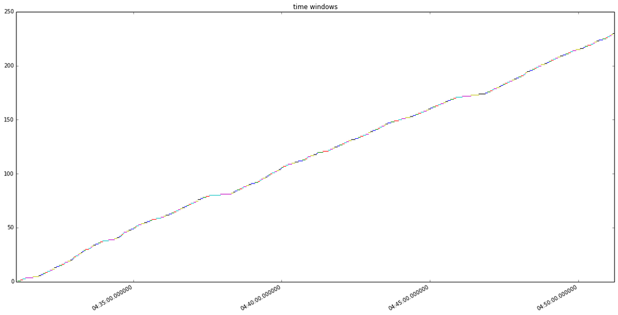

```python
#build a list of times
s = [liveSet.time.min() - datetime.timedelta(seconds=timePadding)]#begining of time space
m = list(liveSet.time)                                            #all the detection times
e = [liveSet.time.max() + datetime.timedelta(seconds=timePadding)]#end of time space
mt = s + m + e

timeWindows = []
for i in range(len(mt)-2):
    #e.g. {'end': Timestamp('2016-10-17 00:21:34.500000+0000', tz='UTC'), 'i': 0, 'start': Timestamp('2016-10-17 00:21:31.500000+0000', tz='UTC')}
    w ={"start": mt[i+0] + (mt[i+1] - mt[i+0])/2,
        "end":   mt[i+1] + (mt[i+2] - mt[i+1])/2,
        "i":i}
    timeWindows.append(w)

timeWindows = pd.DataFrame.from_dict(timeWindows)

plt.title('time windows')
for index, w in timeWindows.iterrows():
    plt.plot([w.start, w.end], [w.i, w.i])
plt.gcf().autofmt_xdate()
plt.show()
```

```python
timeWindows.tail()
```

|  | end | i | start |
| --- | --- | --- | --- |
| 226 | 2016-11-12 04:50:58+00:00 | 226 | 2016-11-12 04:50:54.500000+00:00 |
| 227 | 2016-11-12 04:51:02+00:00 | 227 | 2016-11-12 04:50:58+00:00 |
| 228 | 2016-11-12 04:51:05.500000+00:00 | 228 | 2016-11-12 04:51:02+00:00 |
| 229 | 2016-11-12 04:51:09.500000+00:00 | 229 | 2016-11-12 04:51:05.500000+00:00 |
| 230 | 2016-11-12 04:51:12.500000+00:00 | 230 | 2016-11-12 04:51:09.500000+00:00 |

```python
def timeSliced(timeWindow, df, savePlace, contextDF, personID=304):
    df = h.timeCropDf(df, timeWindow.start, (timeWindow.end - timeWindow.start).total_seconds() )

    fig, ax = plt.subplots()

    timeFormatString = "%H:%M:%S"
    title = "Detections for person {} from {} to {}".format(personID,
                                                            timeWindow.start.strftime(timeFormatString),
                                                            timeWindow.end.strftime(timeFormatString))
    plt.title(title)

    #the sticker labels
    for row in contextDF.iterrows():
        row = row[1] #BS indexing
        ax.text(row.x, row.y, "{0:03d}".format(row.stickerID), fontsize=8)

    #sticker dots
    ax.scatter(contextDF.x, contextDF.y, zorder=20)
    ax.scatter(stickerLocations.x,stickerLocations.y,s=1,c="y")

    #the path
    ax.plot(contextDF.x, contextDF.y, alpha=0.7, linewidth=1, c="g", solid_capstyle='round')

    # Plot all the detections onto the map as pale circles
    ax.scatter(df.x, df.y, zorder=1, s=abs(df.rssiAdj)*100, alpha=0.2)

    #plot the current window's dot bigger
    ax.scatter(contextDF.iloc[timeWindow.i].x,
               contextDF.iloc[timeWindow.i].y,
               zorder=30, s=150, c="r")

    #put the image on the graph as an underlay
    img = imread("map.png")
    ax.imshow(img, zorder=0, extent=[-1300, 72000, -24000, 41000])
    #                                [left,  right, bottom, top  ]

    #put the baseStations on the map
    for index, row in baseStationData.iterrows():
        ax.text(row.x, row.y, row.agentName, fontsize=8)
    ax.scatter(baseStationData.x,baseStationData.y, marker='+')

    #Hide the axis numbers because they don't tell us much
    ax.xaxis.set_major_formatter(plt.NullFormatter())
    ax.yaxis.set_major_formatter(plt.NullFormatter())

#     plt.show() #don't show, we need to save
    fig.savefig(savePlace+"foo"+str(timeWindow.start.strftime(timeFormatString))+".png", bbox_inches='tight')
    fig.clf()
    plt.close()
```

```python
savePlace = 'frames/test1/'
h.clearFolder("/"+savePlace)
#this takes quite a long time if you have a lot of frames
startStopwatch = datetime.datetime.now()
print startStopwatch
for index, w in timeWindows.iterrows():
    if index%10==0:
        print index, datetime.datetime.now() - startStopwatch
    timeSliced(w, bigdf, savePlace, liveSet)

print "That took", datetime.datetime.now() - startStopwatch
```

```
2016-11-12 19:33:20.678720
0 0:00:00.006415
10 0:00:08.661120
20 0:00:17.036675
30 0:00:25.373347
40 0:00:33.751483
50 0:00:42.149384
60 0:00:50.532759
70 0:00:58.898568
80 0:01:07.325978
90 0:01:15.873870
100 0:01:24.269555
110 0:01:32.733264
120 0:01:41.203313
130 0:01:49.638374
140 0:01:58.091713
150 0:02:06.650352
160 0:02:15.054518
170 0:02:23.369715
180 0:02:31.638526
190 0:02:40.001758
200 0:02:48.443045
210 0:02:57.133575
220 0:03:05.592932
230 0:03:14.084356
That took 0:03:14.903302
```

```python
h.makeGif(savePlace + "*.png", "SampleWalk3")
```

```
convert -delay 20 -loop 0 frames/test1/*.png SampleWalk3.gif
```

[figure not shown]

## straight path

[figure not shown]

## not straight path

[figure not shown]